# Pythonの基礎

- 型（int, float, ...）
- if文による分岐
- forループ
- 関数の定義
- モジュール

# Pythonの型 (1)

Pythonは**動的型付け言語**  
型宣言などはなく、型を自動で判別してくれる

- 整数 int: 2
- 実数 float: 2.0
- 複素数 complex: 2+0j

演算子: `+`, `-`, `*`, `/`, `//`（整数部）, `%`（余り）, `**`（べき乗）

```python
a = 2       # 整数
b = 5.0     # 実数
c = -0.5+5j # 複素数

print(a)
print(type(a))
```

```
2
<class 'int'>
```

```python
a = 3
b = 2

print(a**2)
print(a/b) # Python 3.xでは1.5、2.xでは1
```

```
9
1.5
```

# Pythonの型 (2)

- 論理型: True, False

Pythonでは大文字と小文字を区別する

比較演算子: `==, >, <, >=, <=, !=`  
論理演算子: `and, or, not`

```python
a = (3 > 2)  # True
b = (3 == 2) # False

print(a)
print(a and b)
print(a and (not b))
```

```
True
False
True
```

# Pythonの型 (3)

- リスト list: [1, 2, 3]
- タプル tuple: (1, 2, 3)
- 文字列 str: "abc123"

リストやタプルの配列要素は**なんでもよい**... 数、文字列、リスト  
配列要素のインデックスは、原則**0からN-1まで**（Nが配列要素数）  
ただし、-Nから-1までをインデックスに取ることもできる

len(*配列*)は配列要素数を返す

```python
a = [1,3,5,7,9] # a[0], a[1], a[2], a[3], a[4]
print(a[0])
print(a[1])
print(a[-1]) # a[-1]=a[4]
print(len(a))
```

```
1
3
9
5
```

# 配列のスライス（部分配列）

部分配列は、

```
a[start:stop]
a[start:stop:step]
```

などの形で得られる。**部分配列にa[stop]は含まれないことに注意!**  
startを省略すると最初から、stopを省略すると最後まで

```python
a = [1,3,5,7,9]
print(a[1:3]) # [a[1], a[2]]
print(a[::2])
print(a[::-1])
```

```
[3, 5]
[1, 5, 9]
[9, 7, 5, 3, 1]
```

# Pythonの型 (4)

- ユーザー定義型 オブジェクト指向型言語であるPythonでは、ユーザーが新たな型（クラス）を定義できる  
  データ構造だけでなく、演算規則やさまざまなメソッドも

その中でもNumPy ndarrayが特に重要... 高機能な配列計算を提供

# 型変換

Fortranなどと同様に、型の名前の関数を作用させることで型変換できる

```python
a = 100.0
print(a)
print(int(a))
print()
```

```
100.0
100
```

# if文による条件分岐

```
if [論理型]:
    [処理]
elif [論理型]:
    [処理]
else:
    [処理]
```

[論理型]がTrueならば[処理]を行う  
elifはelse ifのこと。ifのみ、if-else、if-elif-elif-...などももちろん可

end ifにあたるものはなく、**インデントによってブロックを判別している**  
インデントは通常スペース4つ

```python
x = 100

if x%2 == 0:
    print("x is even")
else:
    print("x is odd")
```

```
x is even
```

# forループ

```
for i in [配列的なもの]:
    [処理]
```

ダミー変数iは、[配列的なもの]の要素を順に取る

```python
x = "ABC"
for i in x:
    shout = i + "!"
    print(shout)
```

```
A!
B!
C!
```

# rangeを使う

Fortranの`do i = start, stop, step`にあたるループを回したいときは、

```
for i in range(start,stop,step):
    [処理]
```

とすればよい。**range**関数は、startからstopまで、step幅の等差数列を返す  
**stopは含まれない**ことに注意!

range(start,stop)ならstep=1 range(stop)ならstart=0, step=1

```python
for i in range(5): # i=0,1,2,3,4
    print(i**3)
```

```
0
1
8
27
64
```

# 関数の定義と利用

Fortranでいうsubroutineとfunctionは、どちらも**function**として扱われる

```
def func_name(引数):
    処理
    return 戻り値
```

returnはなくても良い

関数を呼ぶときは、

```
func_name(引数)     # returnのない場合
x = func_name(引数) # 戻り値を代入
```

```python
# 引数を3乗して返す関数
def cube(x):
    return x**3

# 引数やreturnがなくても良い
def bark():
    print("Bow-wow!")

y = cube(3) + cube(4) # 27 + 64 = 91
print(y)
bark()
```

```
91
Bow-wow!
```

# モジュールの利用

複数のスクリプトで用いる変数や関数群をひとつの.pyファイルにまとめておき、モジュールとすることができる

```
# my_module.pyの中身
pi = 3.141592

def area(r):
    return pi * r * r
```

これを別のスクリプトで使うには、**import**文を用いる

```python
import my_module

radius = 5.0
S = my_module.area(radius) # my_module内のarea関数

pi = 0
print(pi)                  # このスクリプトの変数pi
print(my_module.pi)        # my_module内の変数pi
```

```
0
3.141592
```

# importいろいろ

```python
import my_module as mm     # 別名をつける
S = mm.area(1.0)

from my_module import area # モジュール内の特定のオブジェクトをインポート
S = area(1.0)
```

# NumPyとは

Pythonの外部ライブラリで、計算のためのさまざまな関数・定数が入っている

特に、NumPyの提供する多次元配列型**NumPy ndarray**は、Pythonでの科学計算の中核となる機能である

# NumPy ndarray

Pythonのリストやタプルは大きなデータを扱うのには向かない

- 基本的に1次元配列
- forループが遅い

NumPy ndarrayは、高速な多次元配列計算を提供するユーザー定義型である

```python
import numpy as np               # NumPyモジュールをインポート
x = np.linspace(0., 2*np.pi,100) # 0から2piまでを100等分する1次元配列
y = np.sin(x)                    # y = sin(x)
```

# ndarrayの生成

### zeros, ones: 0または1で埋まった配列を生成

```
a = np.zeros(10)
b = np.ones((16,16,16))
```

引数に整数またはタプルで配列の形を指定する

```python
a = np.zeros(5)
print(a)

b = np.zeros((3,3))
print(b)
```

```
[ 0.  0.  0.  0.  0.]
[[ 0.  0.  0.]
 [ 0.  0.  0.]
 [ 0.  0.  0.]]
```

### arange, linspace: 等差数列の1次元配列を生成

```
c = np.arange(start, stop, step)
d = np.linspace(start, stop, num)
```

arangeはPython組み込みのrangeと同様  
linspaceは、stepを指定する代わりに分割数numを指定

```python
a = np.arange(0,30,3)
print(a)

b = np.linspace(0,30,3) # 端点を含む等分割
print(b)

c = np.linspace(0,30,3,endpoint=False) # 端点を含まない等分割
print(c)
```

```
[ 0  3  6  9 12 15 18 21 24 27]
[  0.  15.  30.]
[  0.  10.  20.]
```

# ndarrayの基本操作

```python
a = np.arange(10)
b = 2*a + 1    # ベクトル計算が可能
c = np.exp(a)  # numpy内の関数も！
```

```python
a = np.ones((3,3)) # 3x3, 成分はすべて1
a[0,0] = 5         # (0,0)成分に5を代入
a[1,0:2] = 3       # (1,0)、(1,1)成分に3を代入
a[2,:] = np.arange(3) # (2,:)成分に0,1,2を代入
print(a)
```

```
[[ 5.  1.  1.]
 [ 3.  3.  1.]
 [ 0.  1.  2.]]
```

# ndarrayのメソッド

**メソッド: 型（クラス）に固有の関数**

```
オブジェクト名.メソッド名(引数)
```

の形をとる

```python
# 文字列型のメソッド例
a = "I like tomatoes"
b = "12"

print(a.split())
print(a.upper())
print(b.zfill(4))
```

```
['I', 'like', 'tomatoes']
I LIKE TOMATOES
0012
```

# ndarray.reshape(*shape*)

ndarrayをC形式で（後ろのインデックスから順に）平らにした後、*shape*のタプルの形に整列する

```python
a = np.arange(12)
print(a)

b = a.reshape((3,4))
print(b)

c = b.reshape((2,6))
print(c)
```

```
[ 0  1  2  3  4  5  6  7  8  9 10 11]
[[ 0  1  2  3]
 [ 4  5  6  7]
 [ 8  9 10 11]]
[[ 0  1  2  3  4  5]
 [ 6  7  8  9 10 11]]
```

# ndarray.sum(*axis*)

axis（整数またはタプル）で指定した軸に沿って和をとる  
指定しなければ全体の和を取る  
mean（平均）、max（最大）、min（最小）、var（分散）、std（標準偏差）なども同様

```python
a = np.arange(9).reshape((3,3))
print(a)
print(a.sum(0))
print(a.sum())
print(a.max(0))
```

```
[[0 1 2]
 [3 4 5]
 [6 7 8]]
[ 9 12 15]
36
[6 7 8]
```

# ndarray.T

転置をとる

# ndarray.ravel()

多次元配列を（デフォルトではC形式で）1次元にする

# ndarray.shape

配列の形（各次元の要素数）をタプルで返す

# NumPyその他

### 関数（ndarrayに作用させられる！）

sin, cos, exp, sqrt, floor, ceil, ...

### 数

pi, e, inf, nan, ...

```python
x = np.linspace(0., 2*np.pi, 100) # 0から2piまでを100等分
y = np.sin(x)
```

### サブモジュール

- **random** 乱数の生成に関するモジュール
- **fft** 高速フーリエ変換
- **linalg** 線形代数
- **interp** 補間

各モジュールともSciPyにより高機能なものが入っているが、こちらで十分なこともしばしば

```python
x = np.random.rand(8)
print(x)

fx = np.fft.rfft(x)
print(fx)
```

```
[ 0.33686208  0.39706649  0.4032407   0.78413155  0.1172098   0.74075018
  0.29518758  0.59386633]
[ 3.66831470+0.j         -0.15790661+0.00043013j -0.24435640+0.2401812j
  0.59721117+0.21653636j -1.36331440+0.j        ]
```

# forループを使ってはいけない！

ほかの多くのスクリプト言語と同様、Pythonのループは遅い  
NumPyのベクトル演算機能を活かし、forループをできるだけ無くそう

```python
%%time
x = np.linspace(0,2*np.pi,100000)
y = np.sin(x)
```

```
CPU times: user 12 ms, sys: 4 ms, total: 16 ms
Wall time: 16.7 ms
```

```python
%%time
x = np.linspace(0,2*np.pi,100000)
y = np.zeros(100000)
for i in range(100000):
    y[i] = np.sin(x[i])
```

```
CPU times: user 264 ms, sys: 0 ns, total: 264 ms
Wall time: 263 ms
```

# Matplotlibによる可視化

サブモジュールmatplotlib.pyplotによって、Matlab風のスクリプトで可視化できる

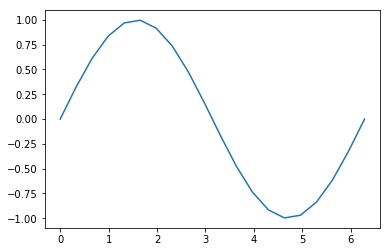

```python
import matplotlib.pyplot as plt
x = np.linspace(0, 2*np.pi, 20)
y = np.sin(x)

plt.plot(x, y)
plt.show()
```

# plt.plot(*x*, *y*)

前の例のように、*x*や*y*はNumPy ndarrayでもよい

オプション変数としては、

- color: "b", "blue", "#0000FF", ...
- linestyle: "-", "--", ".", "o", "o-", ...
- linewidth: 実数
- label: 凡例用文字列

などなど

# plt.contour(*X*, *Y*, *Z*, *N*または*V*), plt.contourf

コンター図（contourfは塗ってくれる）  
*X*,*Y*はプロットする配列*Z*の定義点のx座標およびy座標

```
X,Y = np.meshgrid(x,y,indexing='ij')
```

で生成できる

*N*（整数）を入れると、N段階でいい感じに線を引いてくれる  
*V*（ndarrayなど）を入れると、線を引くところを自分で指定できる

カラーバーは

```
plt.colorbar()
```

の1行！

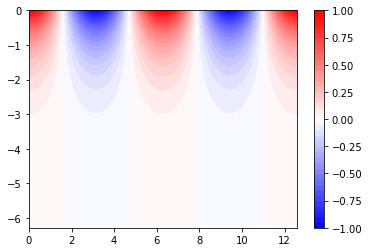

```python
x = np.linspace(0, 4*np.pi, 60)
y = np.linspace(-2*np.pi, 0, 30)
X,Y = np.meshgrid(x, y, indexing="ij") # (Nx, Ny)型の配列をプロットする場合はindexing="ij"をつける

u = np.cos(x.reshape(60,1))*np.exp(y.reshape((1,30))) # broadcastを使って60x30のndarrayを生成

plt.contourf(X, Y, u, 40, cmap="bwr")
plt.colorbar()
plt.show()
```

# plt.quiver(*X*,*Y*, *U*, *V*)

矢印図  
*X*,*Y*はプロットするベクトル(*U*,*V*)の定義点のx座標およびy座標

# plt.hist(*x*)

ヒストグラム

# plt.semilogx(*x*,*y*), semilogy, loglog

片対数・両対数版のplt.plot

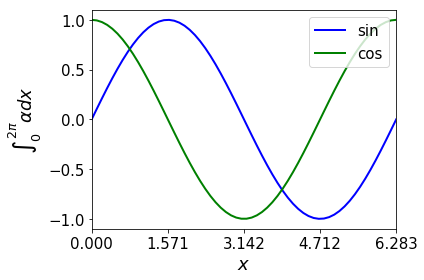

```python
x = np.linspace(0, 2*np.pi, 60)
ys = np.sin(x)
yc = np.cos(x)

fig = plt.figure()
ax = plt.subplot()
ax.plot(x, ys, "b-", lw=2, label="sin")
ax.plot(x, yc, "g-", lw=2, label="cos")
ax.legend(loc="upper right", fontsize=15)
ax.set_xlim(0,2*np.pi)
ax.set_xticks(np.pi * np.linspace(0,2,5))
ax.set_xlabel("$x$", size=18)
ax.set_ylim(-1.1,1.1)
ax.set_ylabel(r"$\int_0^{2\pi}\alpha dx$", size=18)
ax.tick_params(labelsize=15)
fig.tight_layout()
plt.show()
```

# 実用編1: NetCDFの読み込み

**必要なライブラリ**: NetCDF4, HDF4

```python
from netCDF4 import Dataset

data = Dataset("../../../python/hs_2016010100.nc", "r", format="NETCDF4")
print(data.variables.keys())
# data.variablesにはdictionary形式でデータが格納されている。
# .keys()はdictionaryのメソッドで、dictionaryのインデックスを返してくれる
```

```
odict_keys(['longitude', 'latitude', 'time', 'swh'])
```

```python
lon = data.variables["longitude"][:] # 最後の[:]をつけるとnumpy array形式で変数が得られる
lat = data.variables["latitude"][:]
Hs = data.variables["swh"][:]
```

# 実用編2: 地図を描く

**必要なライブラリ**: Basemap (Matplotlib toolkits)

```python
from mpl_toolkits.basemap import Basemap

plt.figure(figsize=(8,6))
bm = Basemap(projection="cyl", # Equidistant Cylindrical projection
            llcrnrlon=0, llcrnrlat=-70,
            urcrnrlon=360, urcrnrlat=70)

bm.drawcoastlines(linewidth=0.25) # 海岸線
bm.drawmeridians(np.arange(0, 360, 30)) # 経線
bm.drawparallels(np.arange(-90, 90, 30)) # 緯線
```

```
{-60: ([<matplotlib.lines.Line2D at 0x7f7f7e236198>], []),
 -30: ([<matplotlib.lines.Line2D at 0x7f7f7e236940>], []),
 0: ([<matplotlib.lines.Line2D at 0x7f7f7e23b160>], []),
 30: ([<matplotlib.lines.Line2D at 0x7f7f7e23b940>], []),
 60: ([<matplotlib.lines.Line2D at 0x7f7f7e243160>], [])}
```

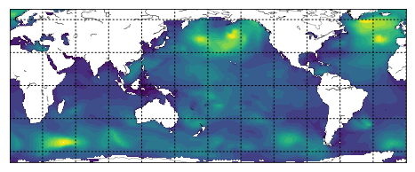

```python
# ここからはmatplotlibの「丁寧な」描き方とほぼ同じ

X, Y = np.meshgrid(lon,lat)
x, y = bm(X, Y) # X, Yはdegree単位だが、basemapで使えるように変換してくれる

# Hsの図を描く
lev = np.linspace(0, 8, 20)
bm.contourf(x, y, Hs[0,:,:], lev)
plt.show()
```

# まとめ - 本日の内容

- Pythonの基礎
  - Pythonの型
  - 基本文法: 分岐、ループ、関数、モジュール
- NumPyの基礎
  - NumPy ndarrayの生成、操作
  - NumPyの関数、モジュール
- Matplotlibの基礎
  - 簡単な作図: plot, contour
- 実用例
  - NetCDFの読み込み、Basemapによる地図の描画

# 参考資料

- [Python公式チュートリアル](https://docs.python.org/3/tutorial/)
- [Scipy Lecture Notes](http://www.scipy-lectures.org/)（[日本語](http://www.turbare.net/transl/scipy-lecture-notes/index.html)）

NumPy: "numpy (やりたいこと)"などでググると結構出てきます。SciPyも同様。公式ドキュメントがわかりやすいです  
Matplotlib: [公式ドキュメント](http://matplotlib.org/api/pyplot_api.html)がわかりにくいですが、[ギャラリー](http://matplotlib.org/gallery.html)は充実しており、それぞれの図についてソースコードを見られるため、描きたい図に近いものを見つけて勉強できます